# team

Emily Pollock, Nick Cory

2/19/21

### Loading in Data

```r
choco <- read.csv("https://raw.githubusercontent.com/xdaiISU/ds202materials/master/hwlabs/data/choco.csv")
```

## Searching for the Best Chocolates

#### 1. How are the ratings distributed? Create both a histogram and a boxplot and describe them. Don’t forget to mention outliers, if there are any.

Looking at the histogram, the ratings distribution is skewed to the left, and there is a gap where there are no ratings between 3.0 and 3.2. Outliers exist from ratings 1 to 2. These outliers make the rating distribution left skewed. The boxplot also shows these outliers clearly, as well as shows the median for ratings is around 3.3.

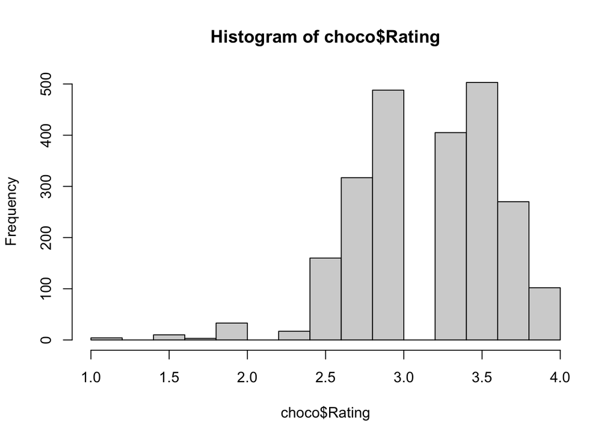

```r
hist(choco$Rating)
```

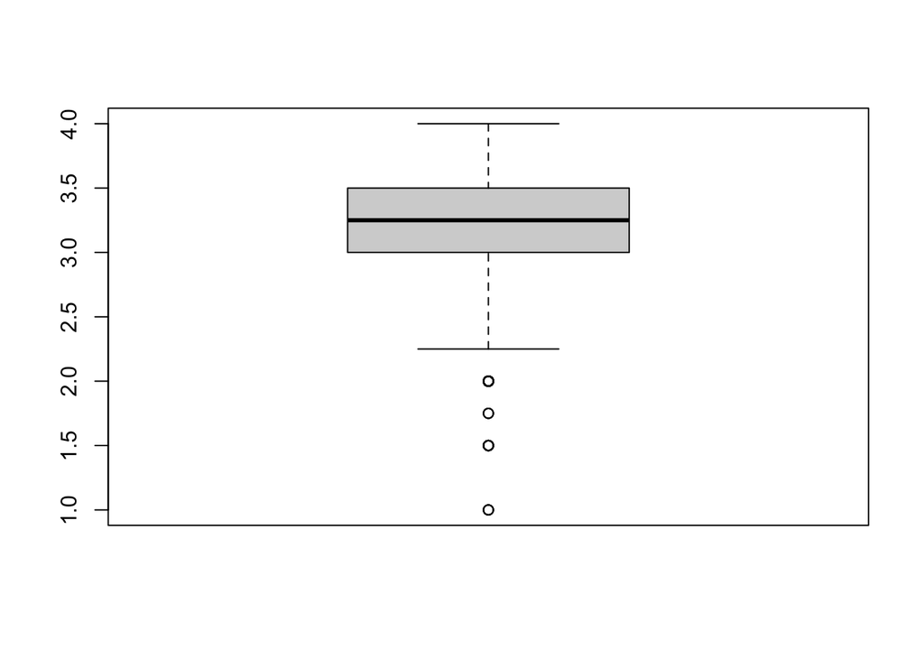

```r
boxplot(choco$Rating)
```